Ternary diagrams are triangular plots of three variables that sum to a constant, typically 100%. First introduced by [August Mobius](https://en.wikipedia.org/wiki/August_Ferdinand_M%C3%B6bius) in 1827, they are sometimes called simplex plots, Gibbs triangles, or de Finetti diagrams. Ternary diagrams are commonly used within the geosciences as classification/discrimination diagrams.

Below are examples of common ternary diagrams used in the earth sciences: the USDA soils classification diagram and the Sheperd’s Sediment classification diagram.

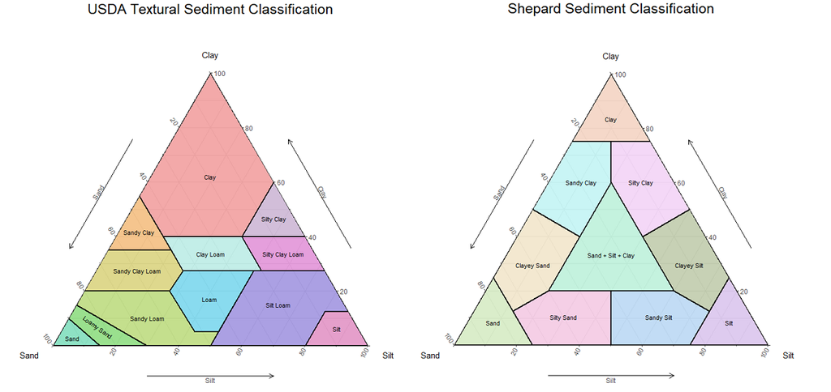

Other notable ternary diagrams in the earth sciences include the [QFL diagram](https://en.wikipedia.org/wiki/QFL_diagram), [QAPF diagram](https://en.wikipedia.org/wiki/QAPF_diagram), and a large variety of [ternary phase diagrams](https://serc.carleton.edu/research_education/equilibria/ternary_diagrams.html).

## Plotting Onto a Ternary Diagram

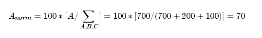

Thus, after normalization the above data point becomes (A = 70, B = 20, C = 10).

Adding a point to a ternary diagram is relatively simple once you get your head around how points move along the axes. Because we plot normalized data onto a ternary plot, all axes are in units of percent (%) and the values range from 0 to 100 (sometimes 0 to 1). The maximum for each ternary axis is located at the triangle node with the axis label. Zero for the any ternary axis is located along the line **opposite the axis label**. So, to move along a ternary axis you start at the line opposite the axis label and then move perpendicularly away from the line toward the axis label.

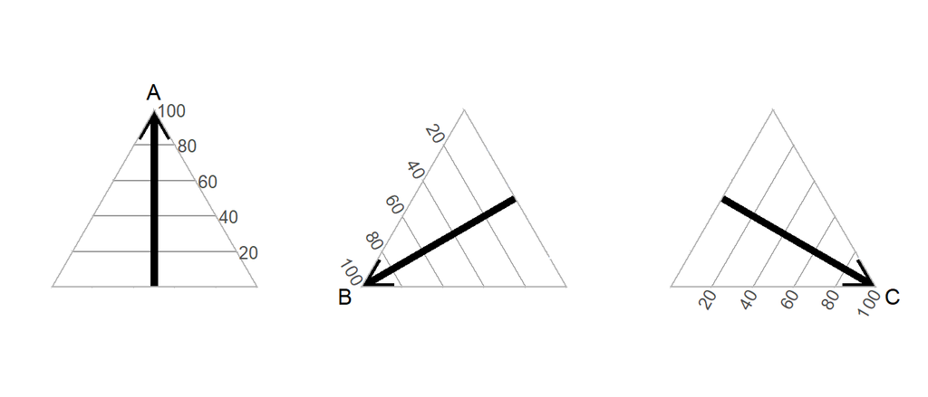

Thus, our example point from above (A = 70, B = 20, C = 10) will plot on a ternary diagram like so.

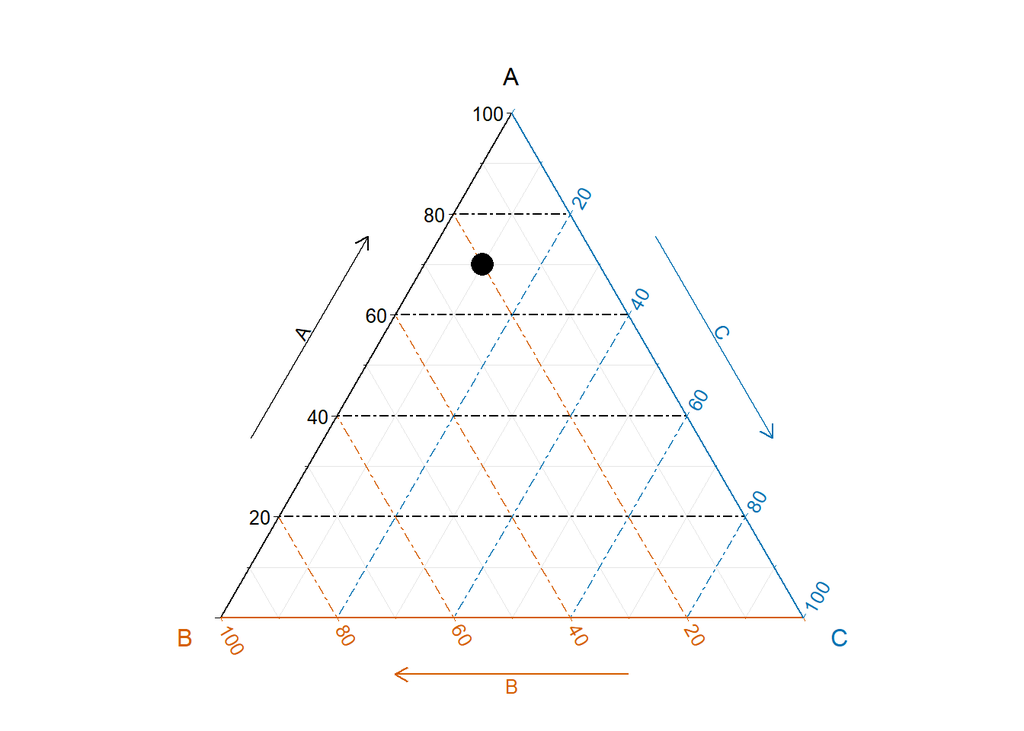

In practice, you will generally only need two coordinates to find a point location on a ternary plot. This is because ternary points always sum to 100, so after plotting a point on axis A and B, axis C will be solved.

## Pay attention to the axes!

It is important to note the axes of a ternary plot can rotate clockwise or counter-clockwise without changing the position where a point will plot. Only the order of the axes around the triangle controls where a point will plot. For example, the point below does not shift if the axis rotation changes; however, if the arrangement of axes changes, it shifts.

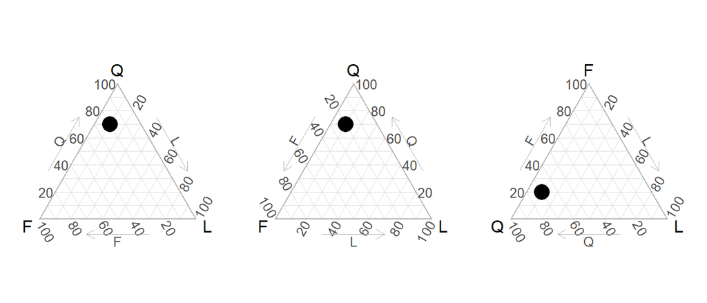